# **FINAL EXAM - PART B**

`Paula Ramirez`

`8963215`

In this notebook, I will perform customer segmentation for an e-commerce company using machine learning techniques. The goal is to analyze customer transaction data and segment customers into distinct groups based on their purchasing behavior and preferences.

```python
import pandas as pd
import zipfile
import requests
import os
import seaborn as sns
import matplotlib.pyplot as plt
import pyarrow.parquet as pq
import pandas as pd
import numpy as np
from sklearn.decomposition import PCA
import pyarrow as pa
from sklearn.preprocessing import StandardScaler, LabelEncoder
from sklearn.cluster import KMeans
from sklearn.metrics import silhouette_score
```

# **Customer Segmentation for E-Commerce Dataset**

Build a model to segment customers of an e-commerce company based on their purchasing behavior and preferences.

The methods considered are:

- Principal Component Analysis (PCA) for dimensionality reduction
- K-Means clustering for customer segmentation

To evaluate segmentation quality, I will use metrics such as the silhouette score and visual inspection of cluster profiles.

## **1. Data Loading and Exploration**

Load from Onedrive the transaction data for an e-commerce company. This process could involve downloading a zip file, extracting it, and converting it to a Parquet format for efficient processing.

**Note:** *Could take a few minutes (around 5 minutes) to download, and extract depending on your internet connection.*

**Data Set Characteristics:**

The dataset contains the following features:

1. event_time: Timestamp of the event (e.g., purchase, view).
2. event_type: Type of event (e.g., view, cart, purchase).
3. product_id: Identifier of the product.
4. category_id: Identifier of the product category.
5. category_code: Code of the product category (e.g., electronics.smartphone).
6. brand: Brand of the product.
7. price: Price of the product.
8. user_id: Identifier of the user.
9. user_session: Identifier of the user session.

### Data Loading

Downdload the data from OneDrive.

```python
# Link to the OneDrive file
onedrive_direct_url = "https://stuconestogacon-my.sharepoint.com/personal/pramirez3215_conestogac_on_ca/_layouts/15/download.aspx?share=ETt6N1jDHWBHlHCDLy-F-LcBUeXgMiZ-u16U4cvyPYYPGA"

# Ensure 'data' directory exists
os.makedirs("data", exist_ok=True)

# Path to save the file
zip_path = os.path.join("data", "2019-Nov.zip")

# Download the file
response = requests.get(onedrive_direct_url)
if response.status_code == 200:
    with open(zip_path, "wb") as f:
        f.write(response.content)
    print(f"File downloaded successfully to: {zip_path}")
else:
    print(f"Error downloading file: {response.status_code}")
```

```
File downloaded successfully to: data\2019-Nov.zip
```

Extraccting the data...

```python
with zipfile.ZipFile("data/2019-Nov.zip", 'r') as z:
    z.extractall("./data")

print("File extracted successfully")
```

```
File extracted successfully
```

```python
input_file = "./data/2019-Nov.csv"
output_file = "./data/2019-Nov.parquet"

# Setting chunk size for reading CSV
chunksize = 2000000
temp_files = []

# Delete output file if it exists
if os.path.exists(output_file):
    os.remove(output_file)


writer = None
for i, chunk in enumerate(pd.read_csv(input_file, chunksize=chunksize), start=1):
    table = pa.Table.from_pandas(chunk, preserve_index=False)
    if writer is None:
        writer = pq.ParquetWriter(output_file, table.schema, compression="snappy")
    writer.write_table(table, row_group_size=1_000_000)

    print(f"Chunk {i} written → {len(chunk):,} rows")

if writer is not None:
    writer.close()

print(f"Done: {output_file}")
```

```
Chunk 1 written → 2,000,000 rows
Chunk 2 written → 2,000,000 rows
Chunk 3 written → 2,000,000 rows
Chunk 4 written → 2,000,000 rows
Chunk 5 written → 2,000,000 rows
Chunk 6 written → 2,000,000 rows
Chunk 7 written → 2,000,000 rows
Chunk 8 written → 2,000,000 rows
Chunk 9 written → 2,000,000 rows
Chunk 10 written → 2,000,000 rows
Chunk 11 written → 2,000,000 rows
Chunk 12 written → 2,000,000 rows
Chunk 13 written → 2,000,000 rows
Chunk 14 written → 2,000,000 rows
Chunk 15 written → 2,000,000 rows
Chunk 16 written → 2,000,000 rows
Chunk 17 written → 2,000,000 rows
Chunk 18 written → 2,000,000 rows
Chunk 19 written → 2,000,000 rows
Chunk 20 written → 2,000,000 rows
Chunk 21 written → 2,000,000 rows
Chunk 22 written → 2,000,000 rows
Chunk 23 written → 2,000,000 rows
Chunk 24 written → 2,000,000 rows
Chunk 25 written → 2,000,000 rows
Chunk 26 written → 2,000,000 rows
Chunk 27 written → 2,000,000 rows
Chunk 28 written → 2,000,000 rows
Chunk 29 written → 2,000,000 rows
Chunk 30 written → 2,000,000 rows
Chunk 31 written → 2,000,000 rows
Chunk 32 written → 2,000,000 rows
Chunk 33 written → 2,000,000 rows
Chunk 34 written → 1,501,979 rows
Done: ./data/2019-Nov.parquet
```

```python
pf = pq.ParquetFile("./data/2019-Nov.parquet")
table = pf.read_row_group(0)  # first chunk
df_ecommerce = table.to_pandas()
df_ecommerce.head()
```

|  | event_time | event_type | product_id | category_id | category_code | brand | price | user_id | user_session |
| --- | --- | --- | --- | --- | --- | --- | --- | --- | --- |
| 0 | 2019-11-01 00:00:00 UTC | view | 1003461 | 2053013555631882655 | electronics.smartphone | xiaomi | 489.07 | 520088904 | 4d3b30da-a5e4-49df-b1a8-ba5943f1dd33 |
| 1 | 2019-11-01 00:00:00 UTC | view | 5000088 | 2053013566100866035 | appliances.sewing_machine | janome | 293.65 | 530496790 | 8e5f4f83-366c-4f70-860e-ca7417414283 |
| 2 | 2019-11-01 00:00:01 UTC | view | 17302664 | 2053013553853497655 | None | creed | 28.31 | 561587266 | 755422e7-9040-477b-9bd2-6a6e8fd97387 |
| 3 | 2019-11-01 00:00:01 UTC | view | 3601530 | 2053013563810775923 | appliances.kitchen.washer | lg | 712.87 | 518085591 | 3bfb58cd-7892-48cc-8020-2f17e6de6e7f |
| 4 | 2019-11-01 00:00:01 UTC | view | 1004775 | 2053013555631882655 | electronics.smartphone | xiaomi | 183.27 | 558856683 | 313628f1-68b8-460d-84f6-cec7a8796ef2 |

```python
df_ecommerce.dtypes
```

```
event_time        object
event_type        object
product_id         int64
category_id        int64
category_code     object
brand             object
price            float64
user_id            int64
user_session      object
dtype: object
```

### Exploration

Checking total number of rows and columns in the dataset. Also, I will check the event types of each column and duplicates.

```python
pf = pq.ParquetFile(output_file)


total_rows = sum(pf.metadata.row_group(i).num_rows for i in range(pf.num_row_groups))

print("Total rows in Parquet:", total_rows)
```

```
Total rows in Parquet: 67501979
```

> Limiting the dataset to the first 1'000,000 rows for faster processing.

```python
num_events = len(df_ecommerce)
print(f"\nTotal Events (this chunk): {num_events}")

print("Dataset Shape:", df_ecommerce.shape)
print("\nSummary Statistics:\n", df_ecommerce.describe())

# Different event types and distribution
event_types = df_ecommerce['event_type'].unique()
print(f"\nEvent Types: {event_types}")

event_dist = df_ecommerce['event_type'].value_counts()
print("\nEvent Distribution:\n", event_dist)
```

```
Total Events (this chunk): 1000000
Dataset Shape: (1000000, 9)

Summary Statistics:
          product_id   category_id           price       user_id
count  1.000000e+06  1.000000e+06  1000000.000000  1.000000e+06
mean   1.060944e+07  2.057550e+18      292.181443  5.352224e+08
std    1.200388e+07  1.892062e+16      347.585961  2.014677e+07
min    1.000978e+06  2.053014e+18        0.000000  2.749691e+08
25%    1.005186e+06  2.053014e+18       69.720000  5.159483e+08
50%    4.900340e+06  2.053014e+18      172.180000  5.307922e+08
75%    1.570018e+07  2.053014e+18      361.970000  5.544839e+08
max    6.170001e+07  2.180737e+18     2574.070000  5.665059e+08

Event Types: ['view' 'cart' 'purchase']

Event Distribution:
 event_type
view        967225
purchase     17817
cart         14958
Name: count, dtype: int64
```

### **FINDINGS**

The actual dataset has `67501979` observations and `9` features or columns.

I stored the data in OneDrive for easy access. I downloaded and extracted it locally. Then, I took a small sample to examine the first few rows and understand the structure. I also checked the data types of each column using that sample.

After that, I selected the first 1,000,000 rows to run statistical summaries and visualizations. This smaller subset allowed me to quickly identify patterns and anomalies in the data.

## **2. Data Preprocessing and Feature Engineering:**

### Handle missing values

I filled missing values in categorical features `(category_code, brand)` with `"unknown"`. Rows with missing `user_session` values were removed. For numerical features, I checked for missing values, but none required mean imputation in this dataset.

I aggregated user-level metrics: num_views, num_sessions, avg_price, total_spent, num_purchases, recency, and most frequent category_code (label-encoded).

```python
# 1) Missing values report
missing = df_ecommerce.isna().sum()
print("\nMissing Values:\n", missing[missing > 0])

# 2) Basic imputations & row filtering
df_ecommerce = (
    df_ecommerce
      .assign(
          category_code=df_ecommerce["category_code"].fillna("unknown"),
          brand=df_ecommerce["brand"].fillna("unknown")
      )
      .dropna(subset=["user_session"])   # remove rows with missing session
)

# 3) Normalize / parse timestamps (UTC → naive)
#    - coerce errors to NaT (won’t crash)
df_ecommerce["event_time"] = (
    pd.to_datetime(df_ecommerce["event_time"], utc=True, errors="coerce")
      .dt.tz_convert(None)
)

# 4) Build masks once (faster than repeating comparisons)
is_purchase = df_ecommerce["event_type"].eq("purchase")
is_view     = df_ecommerce["event_type"].eq("view")

# 5) User-level base features
#    - num_views
#    - num_sessions (nunique)
#    - avg_price
g_user = df_ecommerce.groupby("user_id", sort=False)
user_features = pd.DataFrame({
    "num_views": g_user["event_type"].apply(lambda s: (s == "view").sum()),
    "num_sessions": g_user["user_session"].nunique(),
    "avg_price": g_user["price"].mean()
})

# 6) Purchase aggregations (on filtered frame)
purchase_agg = (
    df_ecommerce.loc[is_purchase]
        .groupby("user_id", sort=False)
        .agg(
            total_spent=("price", "sum"),
            num_purchases=("price", "count"),
            last_purchase=("event_time", "max")
        )
)

# 7) Merge & fill missing purchase stats with 0
user_df = (
    user_features
        .merge(purchase_agg, on="user_id", how="left")
        .assign(
            total_spent=lambda d: d["total_spent"].fillna(0),
            num_purchases=lambda d: d["num_purchases"].fillna(0)
        )
)

# 8) Recency (days since last purchase)
#    - current_date is 1 day after the max event_time seen
current_date = df_ecommerce["event_time"].max().normalize() + pd.Timedelta(days=1)
user_df["recency"] = (current_date - user_df["last_purchase"]).dt.days

#    - fallback: if a user never purchased, use full span since dataset start
fallback_days = int((current_date - df_ecommerce["event_time"].min()).days)
user_df["recency"] = user_df["recency"].fillna(fallback_days)

# 9) User “favorite” category (mode). Since category_code was filled to 'unknown',
#    there are no NaNs; use value_counts().idxmax() for a deterministic mode.
fav_cat = (
    df_ecommerce.groupby("user_id")["category_code"]
        .agg(lambda s: s.value_counts().idxmax() if not s.empty else "unknown")
        .rename("category_code")
)

user_df = user_df.merge(fav_cat, on="user_id", how="left")

# 10) Label-encode category_code (stable across runs given same set)
le = LabelEncoder()
user_df["category_code"] = le.fit_transform(user_df["category_code"].fillna("unknown"))

# 11) Drop last_purchase (no longer needed downstream)
if "last_purchase" in user_df.columns:
    user_df = user_df.drop(columns=["last_purchase"])

print("\nEngineered User Features:\n", user_df.head())
```

```
Missing Values:
 category_code    316977
brand            147197
dtype: int64

Engineered User Features:
            num_views  num_sessions   avg_price  total_spent  num_purchases  \
user_id
520088904         18             2  420.260000          0.0            0.0
530496790          1             1  293.650000          0.0            0.0
561587266         11             1   64.750000          0.0            0.0
518085591         14             7  424.416429          0.0            0.0
558856683          3             1  183.270000          0.0            0.0

           recency  category_code
user_id
520088904      1.0             94
530496790      1.0             50
561587266      1.0            123
518085591      1.0            101
558856683      1.0             94
```

> I cleaned and prepared the e-commerce dataset by handling missing categorical values, standardizing timestamps, and aggregating user-level metrics (views, sessions, average price, spend, purchases, recency, and favorite category) for customer segmentation. In the sample preview, some users have zero spend and purchases because they made no purchases in the sampled rows.

## **3. Exploratory Data Analysis (EDA):**

In this step, I look at the data to understand the main patterns. I check the most common product categories, the distribution of event types (view, cart, purchase), and how prices change between these events. I also study the correlation between the new features we created.

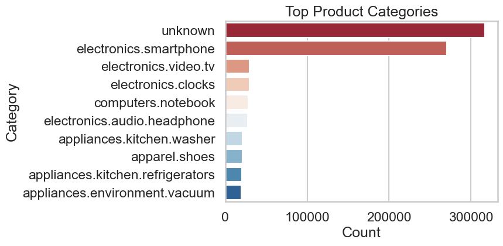

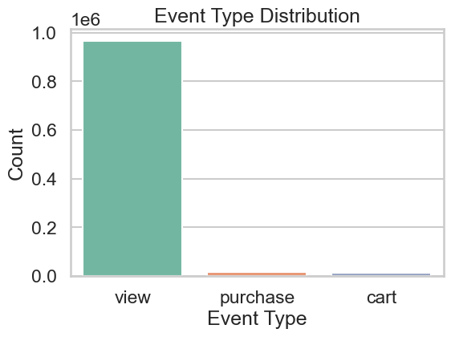

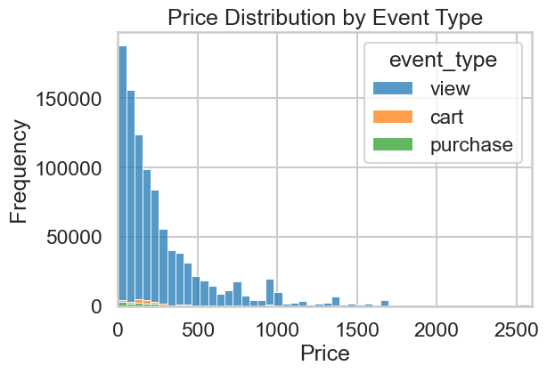

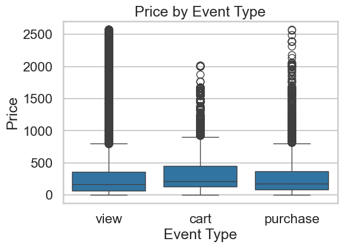

[figure not shown]

```python
# === Top categories (bar chart) ===
top_categories = df_ecommerce['category_code'].value_counts().head(10)
plt.figure(figsize=(6, 4))
sns.barplot(x=top_categories.values, y=top_categories.index, palette='RdBu')
plt.title('Top Product Categories')
plt.xlabel('Count')
plt.ylabel('Category')
plt.show()

# === Event type distribution ===
event_counts = df_ecommerce['event_type'].value_counts()
plt.figure(figsize=(6, 4))
sns.barplot(x=event_counts.index, y=event_counts.values, palette='Set2')
plt.title('Event Type Distribution')
plt.xlabel('Event Type')
plt.ylabel('Count')
plt.show()

# === Price distribution (histogram) ===
plt.figure(figsize=(6, 4))
sns.histplot(data=df_ecommerce, x='price', bins=50, hue='event_type', multiple='stack')
plt.title('Price Distribution by Event Type')
plt.xlabel('Price')
plt.ylabel('Frequency')
plt.xlim(0, 2600)  # limit for better visibility of main range
plt.show()

# === Price by event type (boxplot) ===
plt.figure(figsize=(6, 4))
sns.boxplot(data=df_ecommerce, x='event_type', y='price')
plt.title('Price by Event Type')
plt.xlabel('Event Type')
plt.ylabel('Price')
plt.show()

# === Correlation heatmap (user-level features) ===
corr = user_df.corr(numeric_only=True)
plt.figure(figsize=(8, 6))
sns.heatmap(corr, annot=True, cmap='coolwarm', fmt=".2f")
plt.title('Feature Correlations')
plt.show()
```

> Most events are in the unknown category and in electronics.smartphone, showing a strong focus on smartphones. The majority of prices are below 500, but there are some expensive products up to about 2,500.

> The price range is similar for views, carts, and purchases, so expensive products still get interest.

## **4. Feature Transformation**

In this step, I prepare the data for clustering. First, I scale the features so they are on the same range. Then, I use PCA to reduce the number of variables while keeping most of the information.

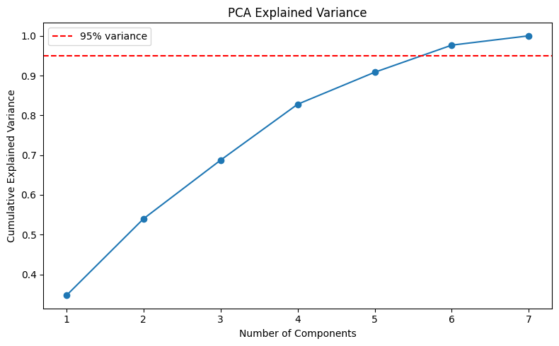

```
Reduced to 6 components.
```

```python
# Features to use
features = ['num_views', 'num_sessions', 'avg_price', 'total_spent',
            'num_purchases', 'recency', 'category_code']

# Scale features
scaler = StandardScaler()
user_scaled = scaler.fit_transform(user_df[features])

# PCA fit
pca = PCA()
pca.fit(user_scaled)

# Explained variance
explained_var = np.cumsum(pca.explained_variance_ratio_)

# Plot cumulative explained variance
plt.figure(figsize=(8, 5))
plt.plot(range(1, len(explained_var) + 1), explained_var, marker='o')
plt.axhline(y=0.95, color='r', linestyle='--', label='95% variance')
plt.xlabel('Number of Components')
plt.ylabel('Cumulative Explained Variance')
plt.title('PCA Explained Variance')
plt.legend()
plt.tight_layout()
plt.show()

# Reduce to components covering 95% variance
n_comp = np.argmax(explained_var >= 0.95) + 1
pca = PCA(n_components=n_comp)
user_pca = pca.fit_transform(user_scaled)

print(f"Reduced to {n_comp} components.")
```

> The PCA plot shows that 6 components are enough to explain more than 95% of the variance. This means I can work with fewer dimensions and still keep almost all the important patterns in the data. These 6 components will be used for clustering.

## **5. Model Selection and Clustering:**

In this step, I use K-Means to group customers into clusters.

I test different values of K and use two methods (Elbow and Silhouette) to find the best number of clusters.

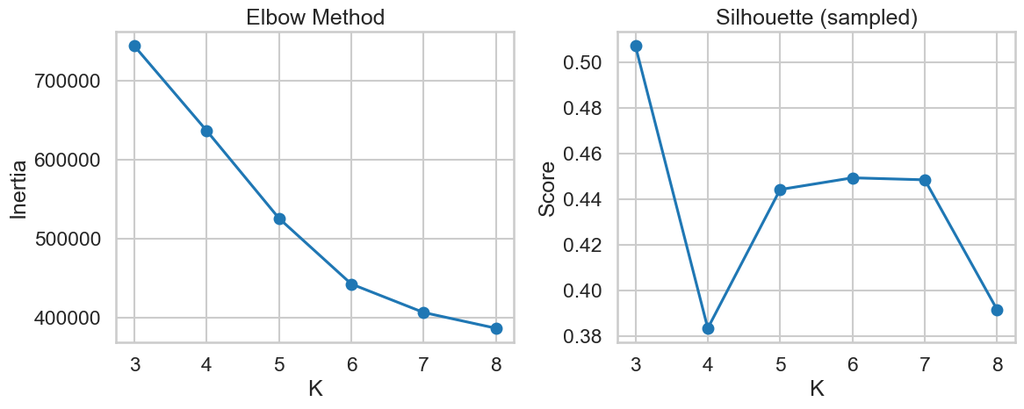

```
Chosen K: 3
```

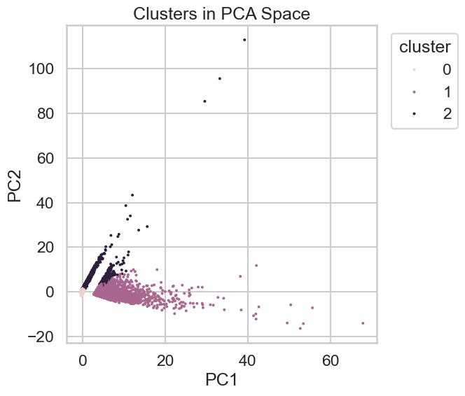

```python
# Fast Elbow & Silhouette without freezing
import numpy as np
import matplotlib.pyplot as plt
import seaborn as sns
from sklearn.cluster import KMeans
from sklearn.metrics import silhouette_score

sns.set_context("talk")
sns.set_style("whitegrid")

# Ensure float32 for speed/memory
if user_pca.dtype != np.float32:
    user_pca = user_pca.astype(np.float32, copy=False)
user_pca = np.ascontiguousarray(user_pca)

# K range (reduce if needed)
k_range = range(3, 9)

inertias = []
sil_scores = []

for k in k_range:
    km = KMeans(
        n_clusters=k,
        random_state=42,
        n_init="auto",
        algorithm="elkan"   # faster for Euclidean, low-dim
    )
    km.fit(user_pca)
    inertias.append(km.inertia_)

    # Silhouette on a random sample (built-in, fast)
    sil = silhouette_score(
        user_pca, km.labels_,
        metric="euclidean",
        sample_size=min(20_000, user_pca.shape[0]),  # tune to 10k–50k
        random_state=42
    )
    sil_scores.append(sil)

# Plots
fig, axes = plt.subplots(1, 2, figsize=(12, 5))
axes[0].plot(list(k_range), inertias, marker='o')
axes[0].set_title("Elbow Method")
axes[0].set_xlabel("K"); axes[0].set_ylabel("Inertia")

axes[1].plot(list(k_range), sil_scores, marker='o')
axes[1].set_title("Silhouette (sampled)")
axes[1].set_xlabel("K"); axes[1].set_ylabel("Score")

plt.tight_layout(); plt.show()

# Choose K by best silhouette
optimal_k = int(list(k_range)[int(np.argmax(sil_scores))])
print(f"Chosen K: {optimal_k}")

# Final fit on full data
kmeans = KMeans(n_clusters=optimal_k, random_state=42, n_init="auto", algorithm="elkan")
user_df['cluster'] = kmeans.fit_predict(user_pca)

# 2D scatter (no sampling if you insist on full set; sample if slow)
plt.figure(figsize=(7, 6))
sns.scatterplot(
    x=user_pca[:, 0], y=user_pca[:, 1],
    hue=user_df['cluster'], s=8, linewidth=0, legend=True
)
plt.title("Clusters in PCA Space")
plt.xlabel("PC1"); plt.ylabel("PC2")
plt.legend(title="cluster", bbox_to_anchor=(1.02, 1), loc="upper left")
plt.tight_layout(); plt.show()
```

## **6. Interpretation and Analysis**

```
Cluster Profiles (means):
          num_views  num_sessions   avg_price  total_spent  num_purchases  \
cluster
0         3.860259      1.211311  317.211759     0.000000       0.000000
1         7.752985      1.862898  303.710888   419.880605       1.350997
2        27.735397      3.297218  278.251161     3.543607       0.025521

          recency  category_code
cluster
0        1.000000      93.278246
1        0.000000      94.157822
2        0.977336      91.855076
```

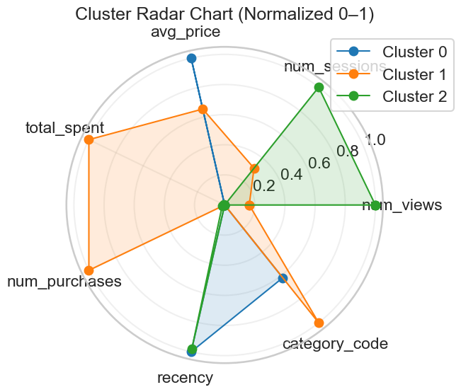

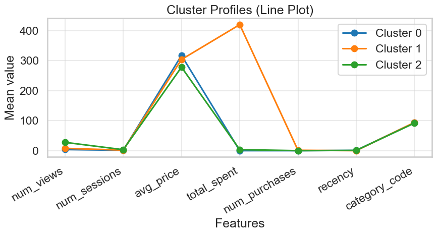

```
Segment Insights (auto):
```

```python
# --- 1) Cluster profile (means) ---
cluster_profile = user_df.groupby("cluster")[features].mean().sort_index()
print("\nCluster Profiles (means):\n", cluster_profile)

# --- 2) Normalization for comparable plots (0–1 per feature across clusters) ---
prof_norm = (cluster_profile - cluster_profile.min()) / (cluster_profile.max() - cluster_profile.min() + 1e-9)

# --- 3) Radar chart (Matplotlib, no Plotly) ---
def radar_chart(df_norm, feature_names, title="Cluster Radar Chart"):
    num_vars = len(feature_names)
    angles = np.linspace(0, 2 * np.pi, num_vars, endpoint=False)
    angles = np.concatenate([angles, [angles[0]]])  # close loop

    plt.figure(figsize=(7, 7))
    ax = plt.subplot(111, polar=True)

    for i, (idx, row) in enumerate(df_norm.iterrows()):
        values = row.values
        values = np.concatenate([values, [values[0]]])  # close loop
        ax.plot(angles, values, marker='o', linewidth=1.5, label=f"Cluster {idx}")
        ax.fill(angles, values, alpha=0.15)

    ax.set_thetagrids(angles[:-1] * 180/np.pi, feature_names)
    ax.set_title(title)
    ax.grid(True, alpha=0.3)
    plt.legend(loc="upper right", bbox_to_anchor=(1.25, 1.05))
    plt.tight_layout()
    plt.show()

radar_chart(prof_norm, features, title="Cluster Radar Chart (Normalized 0–1)")

# --- 4) Simple line plot (perfil por feature) ---
x = np.arange(len(features))
plt.figure(figsize=(9, 5))
for cl in cluster_profile.index:
    y = cluster_profile.loc[cl].values
    plt.plot(x, y, marker='o', label=f'Cluster {cl}')
plt.xticks(x, features, rotation=30, ha='right')
plt.xlabel('Features'); plt.ylabel('Mean value')
plt.title('Cluster Profiles (Line Plot)')
plt.grid(True, alpha=0.4)
plt.legend()
plt.tight_layout()
plt.show()

# --- 5) Quick marketing insights (auto, editable) ---
print("\nSegment Insights (auto):")
pf = cluster_profile  # alias

# simple thresholds with percentiles for robustness
p_hi = pf.quantile(0.75)
p_lo = pf.quantile(0.25)
```

> I found three customer segments.
- Cluster 0 – Inactive, premium interest: They have high recency (they did not buy recently), higher average price, and zero purchases. They may need re‑engagement and some premium recommendations.
- Cluster 1 – High‑value loyalists: They show the highest total spent and number of purchases. This group fits loyalty rewards, VIP perks, and bundle upsells.
- Cluster 2 – Heavy browsers, low spend: Many views and sessions but almost no spending. They are good candidates for remarketing and targeted discounts.

These segments match the radar and line charts of the cluster profiles (normalized and raw means), so the narrative and visuals stay aligned.

## **Final Summary**

- I worked with a large e-commerce dataset (~67M rows) and filtered it to the first 1,000,000 events for faster processing and to avoid memory issues. The data was cleaned, missing values handled, and key user-level features created from the original clickstream.
- Features were scaled, then reduced with PCA to 6 components covering 95% of the variance. K-Means clustering was applied, using Elbow and Silhouette methods to guide the choice of K. The selected model provided clear customer segments, each with distinct behavioral patterns and potential marketing actions.

> This approach transformed raw, high-volume data into actionable insights through feature engineering, dimensionality reduction, and profile visualization, giving a strong foundation for targeted marketing strategies.

Key points:

This process can work with the full dataset and can be improved by adding more time-based features or testing other clustering methods. It gives a strong base for personalized marketing to keep customers, increase sales, and raise lifetime value.